# Problemas de Análisis de la varianza

## Solución

En primer lugar, tenemos que definir la tabla de datos para poder aplicar el test ANOVA:

```r
tarea=c(1,3,5,4,6,2,3,5,7,8,10,6)
tiempo = as.factor(rep(c("0.5","1","1.5","2"),each=3))
(datos=data.frame(tarea,tiempo))
```

```
##    tarea tiempo
## 1      1    0.5
## 2      3    0.5
## 3      5    0.5
## 4      4      1
## 5      6      1
## 6      2      1
## 7      3    1.5
## 8      5    1.5
## 9      7    1.5
## 10     8      2
## 11    10      2
## 12     6      2
```

Una vez definida la tabla, realizamos el contraste ANOVA:

```r
summary(aov(datos$tarea ~ datos$tiempo))
```

```
##              Df Sum Sq Mean Sq F value Pr(>F)
## datos$tiempo  3     42      14     3.5 0.0695 .
## Residuals     8     32       4
## ---
## Signif. codes:  0 '***' 0.001 '**' 0.01 '*' 0.05 '.' 0.1 ' ' 1
```

El p-valor está en la zona de penumbra, es decir, está entre 0.05 y 1. Por tanto, no podemos tomar una decisión clara. Si ponemos como umbral 0.05, podríamos concluir que no tenemos evidencias suficientes para rechazar que los resultados en el entrenamiento son distintos según el tiempo usado.

## Solución

En primer lugar, tenemos que definir la tabla de datos para poder aplicar el test ANOVA:

```r
frecuencias = c(22,25,24,11,21,19,18,16,17,23,26,17,20,31,25,24,16,15,23,24,21,35,23,20)
horas = as.factor(rep(c("9","10","11","12","13","14"),each=4))
meses = as.factor(rep(c("enero","febrero","marzo","julio"),6))
(datos = data.frame(horas,meses,frecuencias))
```

```
##    horas   meses frecuencias
## 1      9   enero          22
## 2      9 febrero          25
## 3      9   marzo          24
## 4      9   julio          11
## 5     10   enero          21
## 6     10 febrero          19
## 7     10   marzo          18
## 8     10   julio          16
## 9     11   enero          17
## 10    11 febrero          23
## 11    11   marzo          26
## 12    11   julio          17
## 13    12   enero          20
## 14    12 febrero          31
## 15    12   marzo          25
## 16    12   julio          24
## 17    13   enero          16
## 18    13 febrero          15
## 19    13   marzo          23
## 20    13   julio          24
## 21    14   enero          21
## 22    14 febrero          35
## 23    14   marzo          23
## 24    14   julio          20
```

Una vez definida la tabla, realizamos el contraste ANOVA:

```r
summary(aov(datos$frecuencias ~ datos$horas + datos$meses))
```

```
##             Df Sum Sq Mean Sq F value Pr(>F)
## datos$horas  5  149.5   29.90   1.395  0.282
## datos$meses  3  149.0   49.67   2.317  0.117
## Residuals   15  321.5   21.43
```

Como los p-valores por horas y por meses son grandes, concluimos que no tenemos evidencias para rechazar que el número de días que llueve por mes no depende ni del mes ni de la hora del día en que llueve.

## Solución

En primer lugar, tenemos que definir la tabla de datos para poder aplicar el test ANOVA:

```r
longitud = c(69,96.1,121,71.3,102.3,122.9,73.2,107.5,123.1,75.1,103.6,125.7,74.4,100.7,125.2,
             75,101.8,120.1,71.1,81,101.1,69.2,85.8,103.2,70.4,86,106.1,73.2,87.5,109.7,
             71.2,88.1,109,70.9,87.6,106.9)
factor.agua = as.factor(rep(c("bajo","medio","alto"),12))
factor.planta = as.factor(rep(c("sin hojas","con hojas"),each=18))
(datos=data.frame(factor.agua,factor.planta,longitud))
```

```
##    factor.agua factor.planta longitud
## 1         bajo     sin hojas     69.0
## 2        medio     sin hojas     96.1
## 3         alto     sin hojas    121.0
## 4         bajo     sin hojas     71.3
## 5        medio     sin hojas    102.3
## 6         alto     sin hojas    122.9
## 7         bajo     sin hojas     73.2
## 8        medio     sin hojas    107.5
## 9         alto     sin hojas    123.1
## 10        bajo     sin hojas     75.1
## 11       medio     sin hojas    103.6
## 12        alto     sin hojas    125.7
## 13        bajo     sin hojas     74.4
## 14       medio     sin hojas    100.7
```

[output cut: 22 more lines]

Una vez definida la tabla, realizamos el contraste ANOVA:

```r
summary(aov(datos$longitud ~ datos$factor.agua * datos$factor.planta))
```

```
##                                       Df Sum Sq Mean Sq F value   Pr(>F)
## datos$factor.agua                      2  10842    5421  734.49  < 2e-16 ***
## datos$factor.planta                    1   1225    1225  165.97 9.27e-14 ***
## datos$factor.agua:datos$factor.planta  2    422     211   28.59 1.12e-07 ***
## Residuals                             30    221       7
## ---
## Signif. codes:  0 '***' 0.001 '**' 0.01 '*' 0.05 '.' 0.1 ' ' 1
```

Como todos los p-valores son pequeños, concluimos lo siguiente:

- tenemos evidencias suficientes para afirmar que la longitud de la planta depende del nivel de agua,
- tenemos evidencias suficientes para afirmar que la longitud de la planta depende del tipo de planta, es decir, si ésta es sin hojas o con hojas y,
- tenemos evidencias suficientes para afirmar que existe interacción entre el nivel de agua y el tipo de planta. Realizemos un gráfico de la interacción para comprobar gráficamente dicha evidencia:

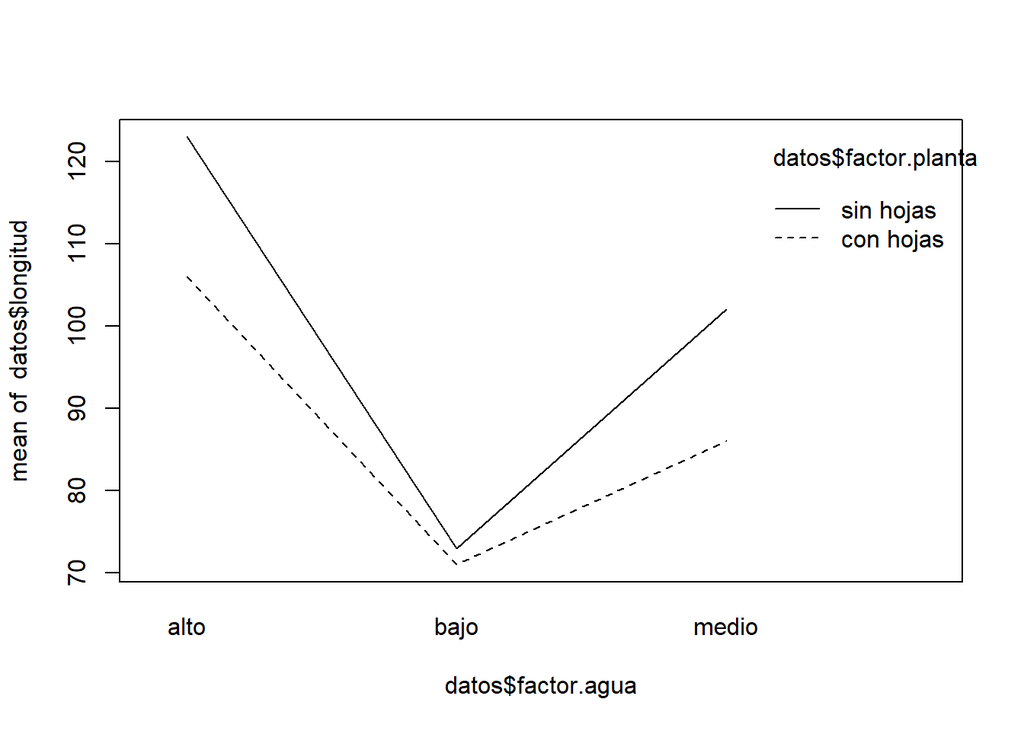

```r
interaction.plot(datos$factor.agua,datos$factor.planta,datos$longitud)
```

Observamos que los segmentos anteriores están lejos de ser paralelos.

## Solución

En primer lugar, tenemos que definir la tabla de datos para poder aplicar el test ANOVA:

```r
valores=c(20,26,26,24,23,26,21,24,22,20,21,21,22,20,16,18,20,21,
          24,15,17,19,15,13,16,12,11,14)
variable.aleatoria = as.factor(rep(c("X1","X2","X3","X4"),each=7))
(datos=data.frame(valores,variable.aleatoria))
```

```
##    valores variable.aleatoria
## 1       20                 X1
## 2       26                 X1
## 3       26                 X1
## 4       24                 X1
## 5       23                 X1
## 6       26                 X1
## 7       21                 X1
## 8       24                 X2
## 9       22                 X2
## 10      20                 X2
## 11      21                 X2
## 12      21                 X2
## 13      22                 X2
## 14      20                 X2
## 15      16                 X3
## 16      18                 X3
## 17      20                 X3
## 18      21                 X3
## 19      24                 X3
## 20      15                 X3
## 21      17                 X3
## 22      19                 X4
## 23      15                 X4
## 24      13                 X4
## 25      16                 X4
## 26      12                 X4
## 27      11                 X4
## 28      14                 X4
```

Para contrastar si las varianzas son iguales, usamos el test de Bartlett:

```r
bartlett.test(valores ~ variable.aleatoria)
```

```
##
##  Bartlett test of homogeneity of variances
##
## data:  valores by variable.aleatoria
## Bartlett's K-squared = 3.4291, df = 3, p-value = 0.3301
```

Como el p-valor es grande, concluimos que no tenemos evidencias suficientes para rechazar que las varianzas de las muestras de las 4 variables aleatorias no sean iguales.

Contrastemos a continuación si las medias son iguales usando el test ANOVA:

```r
summary(aov(valores ~ variable.aleatoria))
```

```
##                    Df Sum Sq Mean Sq F value   Pr(>F)
## variable.aleatoria  3    345  114.99   18.16 2.29e-06 ***
## Residuals          24    152    6.33
## ---
## Signif. codes:  0 '***' 0.001 '**' 0.01 '*' 0.05 '.' 0.1 ' ' 1
```

Como el p-valor es muy pequeño concluimos que tenemos evidencias suficientes para afirmar que las medias de las 4 variables aleatorias no son iguales.